# Qploidy2 Tutorial

# 14 Re-run the HMM with the new standardization

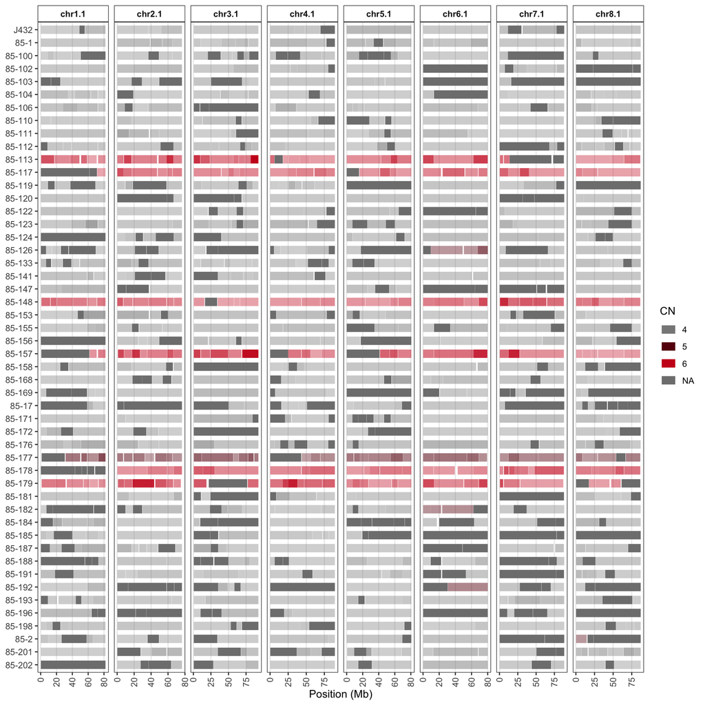

```r
re_multi_esti <- hmm_estimate_CN_multi(
  qploidy_standarize_result = re_qploidy_standardization,
  sample_ids = "all",
  n_cores = 2,
  cn_grid =  c(2,3,4,5,6))

re_multi_esti_filtered <- filter_hmm_CN(re_multi_esti,
                                        min_CN_reliability = 0.05,
                                        min_post_max = 0.25)

# CNV profiles before
compare_cn_track(hmm_CN = multi_esti_filtered,
                 samples_to_plot = samples[1:50],
                 facet_ncol = 8)
```

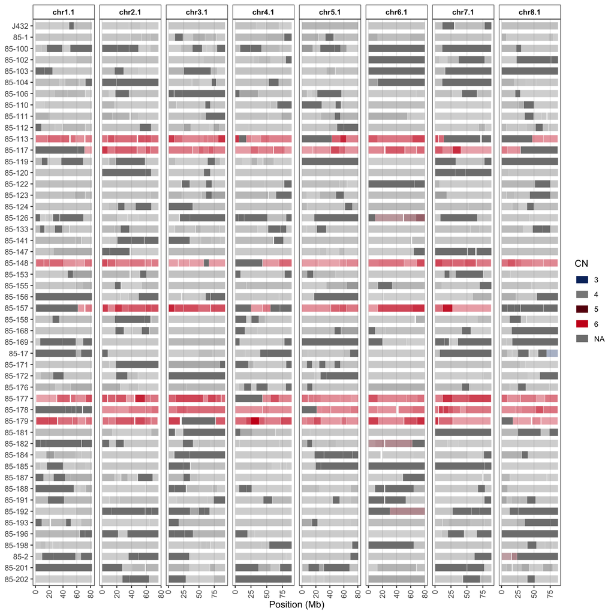

```r
# CNV profiles after
compare_cn_track(hmm_CN = re_multi_esti_filtered,
                 samples_to_plot = samples[1:50],
                 facet_ncol = 8)
```

For this dataset, there are a few changes for some samples.

# 15 Refine results for a single sample

If this instability still leaves doubts about the CNV. You can further explore tweaking the other parameters, for example, increasing the number of markers in the windows to better fit the mixed models on the BAF distributions:

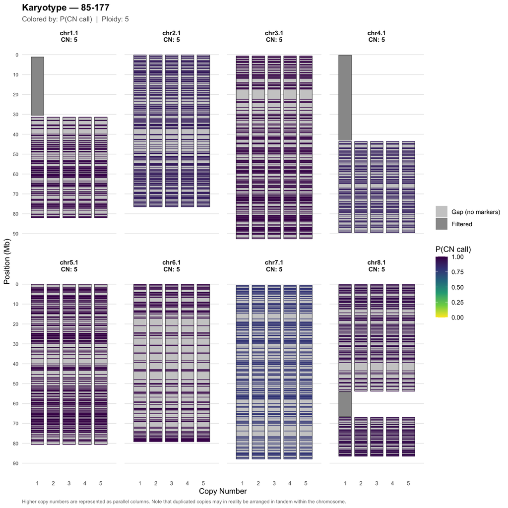

```r
plot_karyotype(multi_esti_filtered, sample_name = "85-177", nrow = 2, color_by = "post_max_CN")
```

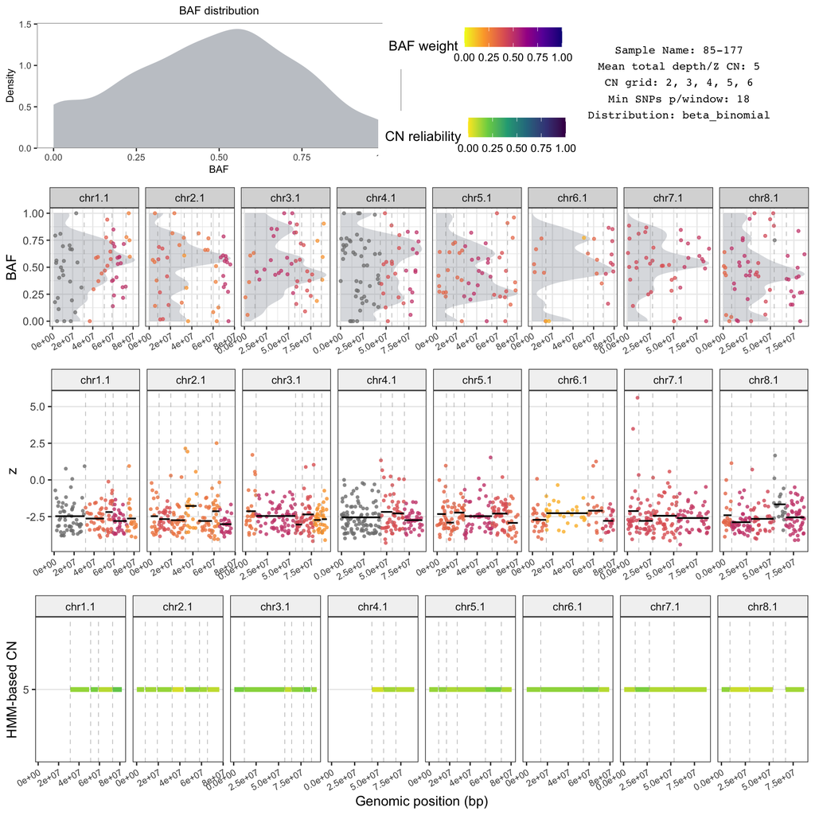

```r
p <- plot_cn_track(hmm_CN = multi_esti_filtered,
                   qploidy_standarize_result = re_qploidy_standardization,
                   sample_id = "85-177",
                   show_window_lines = TRUE)
p$arranged
```

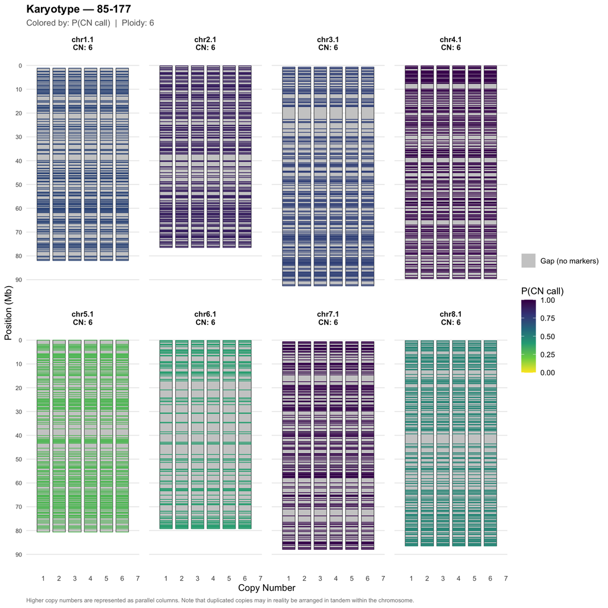

```r
res_tweak <- hmm_estimate_CN(qploidy_standarize_result = re_qploidy_standardization,
                             sample_id = "85-177",
                             min_snps_per_window = 40,
                             cn_grid =  c(2,3,4,5,6))

plot_karyotype(res_tweak, sample_name = "85-177", nrow = 2, color_by = "post_max_CN")
```

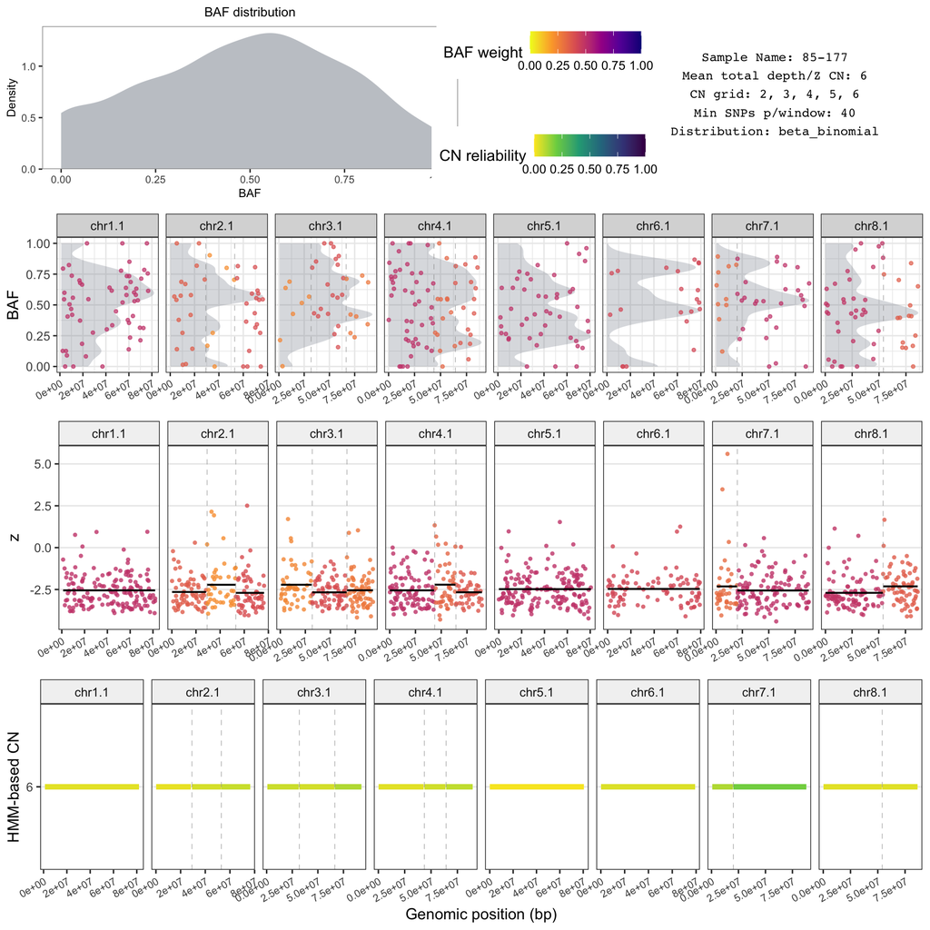

```r
p <- plot_cn_track(hmm_CN = res_tweak,
                   qploidy_standarize_result = re_qploidy_standardization,
                   sample_id = "85-177",
                   show_window_lines = TRUE)

p$arranged
```

The sample estimated as 6x has actually a wide variance where dosage peaks cannot be defined. If peaks have large variance, the CN reliability will be low and the estimation should not be trusted.

Explore more parameters consulting `?hmm_estimate_CN`.

```r
final_res <- update_hmm_CN_multi(re_multi_esti_filtered,
                                 res_tweak,
                                 rm_sample = TRUE)
```

If you decide that the results for this sample is inconclusive, you can set the `rm_sample` parameter to `TRUE` to remove it from your final results.

# 16 Plotting all samples in batches (Optional)

Generate CNV plots for all samples in batches:

```r
n_plots_by_page <- c(seq(1, length(samples), by = 40), length(samples))
for(i in 1:(length(n_plots_by_page) -1)){
  comp_p <- compare_cn_track(hmm_CN = final_res,
                             samples_to_plot = samples[n_plots_by_page[[i]]:n_plots_by_page[i+1]],
                             facet_ncol = 12)
  ggsave(comp_p, filename = paste0("Samples_", n_plots_by_page[i], "_", n_plots_by_page[i +1], ".png"), height = 10, width = 11)
}
```

# 17 Interactive curation of results

**WARNING**: Qploidy2 HMM results accuracy depends on many factors that sometimes the call likelihoods are not capable to detect. We strongly suggest to review the diagnostic plots for non-expected results. The `GenoBrew` tool described below is a great resource to make the graphics evaluation and results curation process quick.

## 17.1 Export HMM results

The resulted objects from function `update_hmm_CN_multi`, `hmm_estimate_CN`, and `hmm_estimate_CN_multi` are all classified as

```r
class(res_tweak) # result from hmm_estimate_CN
```

```
## [1] "hmm_CN"
```

```r
class(multi_esti) # result from hmm_estimate_CN_multi
```

```
## [1] "hmm_CN"
```

```r
class(re_multi_esti_filtered) # result from hmm_estimate_CN_multi after re-standardization
```

```
## [1] "hmm_CN"
```

```r
class(final_res)  # result from update_hmm_CN_multi
```

```
## [1] "hmm_CN"
```

Therefore, all of them can be exported by the function:

```r
write_hmm_CN(final_res, prefix = "alfalfa_example")
```

You will see three generated files:

- “[prefix]_by_marker.csv.gz”
- “[prefix]_by_window.csv.gz”
- “[prefix]_params.rds”

You can read them back to R using the `read_hmm_CN` function:

```r
final_res <- read_hmm_CN(by_marker_file = "alfalfa_example_by_marker.csv.gz",
                         by_window_file = "alfalfa_example_by_window.csv.gz",
                         params_file = "alfalfa_example_params.rds")
```

## 17.2 Deploy `GenoBrew`

The resulted files from `write_hmm_CN` can be uploaded on `GenoBrew` Shiny interface. The tab `CNV profiles` allow you to interactively inspect the BAF, z-score and CN calls plots, re-run the HMM adjusting parameters for specific samples and update the results.

Visit `GenoBrew` GitHub [repository](https://github.com/Breeding-Insight/GenoBrew) and [tutorial](https://scribehow.com/viewer/GenoBrew_Interactive_Marker_Panel_Evaluation_CNV_Visualization_and_Curation__4uWloBuPT1WlnCvW2UWiTg) for more information.

# 18 Call dosages

**Warning**: Beta version - Dosage call requires more testing and review.

Qploidy2 uses the BAF distributions to call dosages. See an example:

```r
# res was generated by hmm_estimate_CN above, it contains only one sample
sample_name <- "85-17"
baf <- final_res$by_marker$baf[final_res$by_marker$SampleName == sample_name]

selected_model <- select_best_baf_model(baf_vec =  baf,
                                        sample = sample_name,
                                        cn_grid= c(2,3,4),
                                        plot = TRUE)

dosages_one_sample <- call_BAF_dosages(baf, selected_model = selected_model, plot=TRUE)
head(dosages_one_sample$data)
```

|  | BAF | dosage | max_prob | dosage_0 | dosage_1 | dosage_2 | dosage_3 | dosage_4 |
| --- | --- | --- | --- | --- | --- | --- | --- | --- |
| 1 | NA | NA | NA | NA | NA | NA | NA | NA |
| 2 | NA | NA | NA | NA | NA | NA | NA | NA |
| 3 | 0.5940055 | 2 | 0.8958922 | 1.593304e-21 | 2.224306e-07 | 0.8958922 | 0.1041075 | 3.49039e-10 |
| 4 | NA | NA | NA | NA | NA | NA | NA | NA |
| 5 | NA | NA | NA | NA | NA | NA | NA | NA |
| 6 | NA | NA | NA | NA | NA | NA | NA | NA |

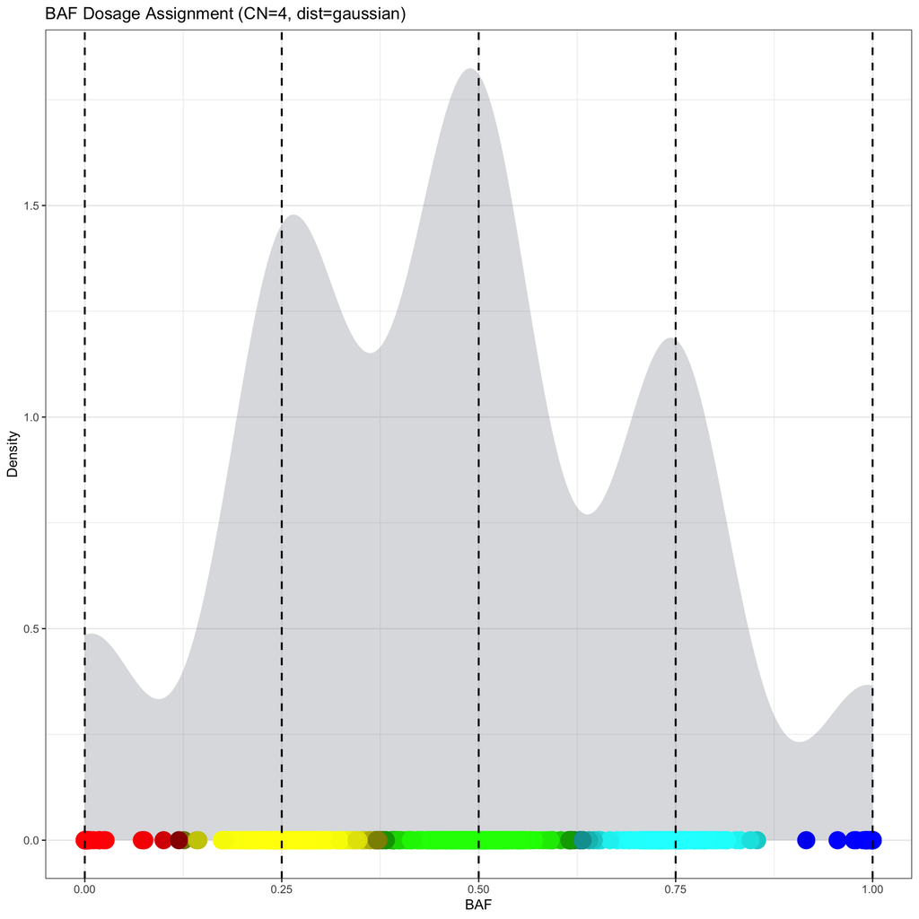

```r
dosages_one_sample$plot
```

Call dosages for all samples considering the copy number estimated:

```r
dosages <- call_hmm_dosages(hmm_CN = final_res, n.cores = 2)
head(dosages)
```

|  | MarkerName | SampleName | Chr | Position | X | Y | baf | z | CN_call | post_max_CN | post_CN2 | post_CN3 | post_CN4 | post_CN5 | post_CN6 | dosage | post_max_dosage | dosage_0 | dosage_1 | dosage_2 | dosage_3 | dosage_4 | dosage_5 | dosage_6 | w_baf |
| --- | --- | --- | --- | --- | --- | --- | --- | --- | --- | --- | --- | --- | --- | --- | --- | --- | --- | --- | --- | --- | --- | --- | --- | --- | --- |
| 85-1.4.2371 | chr1.1_000194324 | 85-1 | chr1.1 | 194324 | 1 | 339 | NA | 1.3816947 | 4 | 0.9848568 | 2.013552e-06 | 0.005495773 | 0.9848568 | 0.009642698 | 2.753987e-06 | NA | NA | NA | NA | NA | NA | NA | NA | NA | 0.5 |
| 85-1.4.2372 | chr1.1_000532584 | 85-1 | chr1.1 | 532584 | 128 | 0 | NA | -0.3143281 | 4 | 0.9848568 | 2.013552e-06 | 0.005495773 | 0.9848568 | 0.009642698 | 2.753987e-06 | NA | NA | NA | NA | NA | NA | NA | NA | NA | 0.5 |
| 85-1.4.2373 | chr1.1_000735393 | 85-1 | chr1.1 | 735393 | 24 | 90 | 0.7747784 | 1.5108092 | 4 | 0.9848568 | 2.013552e-06 | 0.005495773 | 0.9848568 | 0.009642698 | 2.753987e-06 | 3 | 0.9999998 | 4.120051e-82 | 5.103834e-38 | 6.859024e-11 | 0.9999998 | 1.581646e-07 | NA | NA | 0.5 |
| 85-1.4.2374 | chr1.1_000837330 | 85-1 | chr1.1 | 837330 | 158 | 96 | NA | 1.2619504 | 4 | 0.9848568 | 2.013552e-06 | 0.005495773 | 0.9848568 | 0.009642698 | 2.753987e-06 | NA | NA | NA | NA | NA | NA | NA | NA | NA | 0.5 |
| 85-1.4.2375 | chr1.1_000915014 | 85-1 | chr1.1 | 915014 | 36 | 1 | NA | -0.9624907 | 4 | 0.9848568 | 2.013552e-06 | 0.005495773 | 0.9848568 | 0.009642698 | 2.753987e-06 | NA | NA | NA | NA | NA | NA | NA | NA | NA | 0.5 |
| 85-1.4.2376 | chr1.1_001169609 | 85-1 | chr1.1 | 1169609 | 405 | 0 | NA | 1.0462538 | 4 | 0.9848568 | 2.013552e-06 | 0.005495773 | 0.9848568 | 0.009642698 | 2.753987e-06 | NA | NA | NA | NA | NA | NA | NA | NA | NA | 0.5 |

Once you run the dosage call, you can color the karyotype by the dosage or dosage likelihoods:

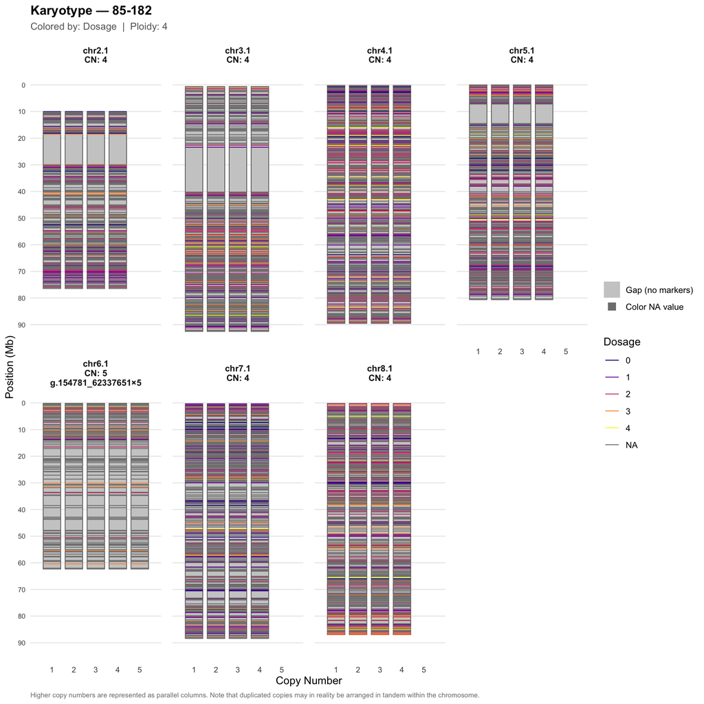

```r
plot_karyotype(dosages, sample_name = "85-182", nrow = 2, color_by = "dosage")
```

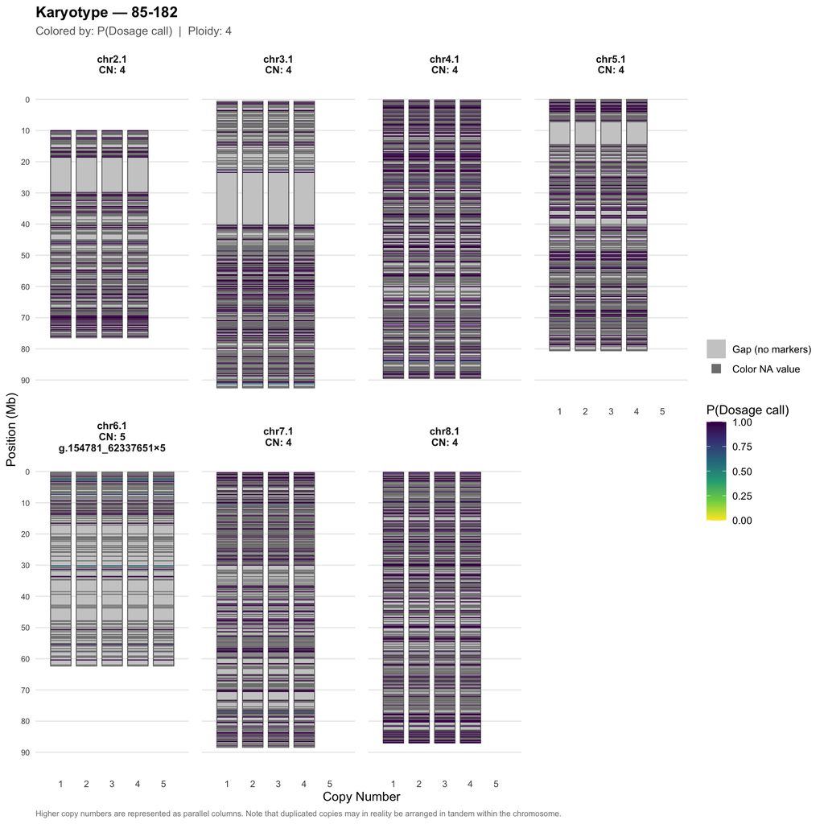

```r
plot_karyotype(dosages, sample_name = "85-182", nrow = 2, color_by = "post_max_dosage")
```